# 8. 프로퍼티 디스크립터 알아보기

```python
from IPython.display import Image
```

## 8-1 클래스메소드, 스태틱 메소드

### 클래스 메소드, 스태틱 메소드 정의

- 클래스 메소드, 스태틱메소드를 내부에 정의된 함수에 데코레이터 처리

```python
class Person :
    name = "클래스 속성"
    def __init__(self, name) :
        self.name = name

    @classmethod
    def getName(cls) :
        return cls.name

    @staticmethod
    def setName(cls, value) :
        cls.name = value
```

## 클래스 메소드는 클래스나 객체에서 사용이 가능

- 첫번째 cls는 자동으로 세팅되어 처리됨

```python
Person.getName()
```

```
'클래스 속성'
```

```python
Person.name
```

```
'클래스 속성'
```

```python
p = Person("객체속성")
```

```python
p.name
```

```
'객체속성'
```

```python
p.getName()
```

```
'클래스 속성'
```

### 스태틱 메소드는 실제 함수를 사용하는 것

- 모든 인자를 전부 넣고 호출해야한다

```python
p.setName(Person, "수정")
```

```python
p.getName()
```

```
'수정'
```

```python
Person.setName(Person, "또 수정")
```

```python
Person.name
```

```
'또 수정'
```

## 8-2 프로퍼티

- 프로퍼티는 함수를 이름으로 호출해서 사용할 수 있는 기법
- 보통 조회, 갱신, 삭제 3개의 함수를 정의한다.

### 클래스의 메소드를 프로퍼티로 정의

- 자주 변경되는 경우 이를 계산된 결과를 처리할 때 프로퍼티를 많이 사용함

```python
class Agreement :
    def __init__(self, seller, buyer, price) :
        self.seller = seller
        self.buyer = buyer
        self.taxrate = 0.1
        self.price = price

    @property
    def Tax(self) :
        return  int(self.price * self.taxrate)

    @Tax.setter
    def Tax(self, taxrate) :
        self.taxrate = taxrate
```

### 객체 생성

```python
a = Agreement('갑','을', 1000)
```

### 이름으로 메소드 접근하면 값을 조회

```python
a.Tax
```

```
100
```

### 이름을 가지고 할당하면 갱신 메소드 사용

```python
a.Tax = 0.2
```

### 다시 이름으로 조회하면 갱신된 것을 반영해서 계산한다

```python
a.Tax
```

```
200
```

## 8-3 디스크립터

### 디스크립터는 별도의 클래스를 정의하고 클래스 속성에 객체를 할당해서 사용하는 방식

- 프로퍼티, 클래스메소드, 스태틱메소드 등도 기본 디스크립터이다

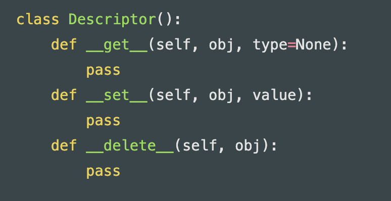

```python
Image("./이미지/디스크립터프로토콜.png", width=400, height=400)
```

### 디스크립터 클래스 정의할 때 초기화 정의없이 변수이름을 세팅하는 방식

```python
class Descriptor :
    def __set_name__(self, owner, name) :
        self._name = "_" + name

    def __get__(self, instance, owner) :
        if not(self._name in instance.__dict__) :
            self.__set__(instance, 0)
        return instance.__dict__[self._name]

    def __set__(self, instance, value) :
        instance.__dict__[self._name] = value
```

### 디스크립터 객체는 반드시 클래스 속성으로 정의한다

```python
class C :
    value = Descriptor()
    value1 = Descriptor()
```

### 클래스 정의를 확인하면 두 개의 디스크립터가 속성으로 정의

```python
C.__dict__
```

```
mappingproxy({'__module__': '__main__',
              'value': <__main__.Descriptor at 0x252b3d53508>,
              'value1': <__main__.Descriptor at 0x252b3d536c8>,
              '__dict__': <attribute '__dict__' of 'C' objects>,
              '__weakref__': <attribute '__weakref__' of 'C' objects>,
              '__doc__': None})
```

### 객체를 하나 생성한다

```python
c = C()
```

### 클래스 속성을 객체로 접근한다

- 실제 객체 내의 속성이 할당되지 않아서 이름으로 접근할 때 먼저 객체에 초기값으로 할당한다.

```python
c.value
```

```
0
```

```python
c.value1
```

```
0
```

### 객체 내에 두 개의 속성이 있는 것을 확인할 수 있다

```python
c.__dict__
```

```
{'_value': 0, '_value1': 0}
```

```python
c.value = 100
```

```python
c.value
```

```
100
```

### 디스크립터 객체를 생성할 때 이름을 받아서 보관한다.

- 클래스 속성과 디스크립터 속성의 이름을 동일하게 처리해야한다.

```python
class Descriptor_old :
    def __init__(self, name) :
        self._name = "_" + name

    def __get__(self, instance, owner) :
        if not(self._name in instance.__dict__) :
            self.__set__(instance, 0)
        return instance.__dict__[self._name]

    def __set__(self, instance, value) :
        instance.__dict__[self._name] = value
```

```python
class D :
    value = Descriptor_old("value")
    value1 = Descriptor_old("value1")
```

```python
d = D()
```

```python
d.value
```

```
0
```

```python
d.value1
```

```
0
```

```python
d.value = 100
```

```python
d.value
```

```
100
```